# COVID19 in the United States: Data by State

Analysis using data from The COVID Tracking Project.

Fernando DePaolis

github page https://github.com/fdp2012/FernandoDePaolis.github.io

24 December, 2020

This site is under construction. Visit it again for updates

## Introduction

In this project, we use the datasets available from [The COVID Tracking Project](https://covidtracking.com/)

### Loading needed libraries

```r
library(pacman) # functions to manage packages (load, path, etc.)
# We load packages using pacman::p-load()
pacman::p_load(httr, jsonlite, tidyverse, forecast, ffp2)
```

For the main R code, we use functions in the following libraries:

- [httr](https://cran.r-project.org/web/packages/httr/) Useful tools for working with HTTP organised by HTTP verbs (GET(), POST(), etc)
- [jsonlite](https://cran.r-project.org/web/packages/jsonline/) A fast JSON parser and generator optimized for statistical data and the web.
- [tidyverse](https://cran.r-project.org/web/packages/tidyverse/) Set of packages for data cleaning and reshaping data
- [fpp2](https://cran.r-project.org/web/packages/fpp2/) All data sets required for the examples and exercises in the book “Forecasting: principles and practice” by Rob J Hyndman and George Athanasopoulos. All packages required to run the examples are also loaded (expsmooth; fma; forecast; ggplot2).

## Processing Current and Historical Data

### Reading datasets

```r
### Interacts with API (application programing interface)
# Current data
ATL_API_curr = GET("https://covidtracking.com/api/v1/states/current.json")  # usually a day or 2 behind
ATL_API_data_curr = fromJSON(rawToChar(ATL_API_curr$content))

# Historical data
ATL_API_hist = GET("https://covidtracking.com/api/v1/states/daily.json")  # usually a day or 2 behind
ATL_API_data_hist = fromJSON(rawToChar(ATL_API_hist$content))
```

#### Removing territories

```r
# removes territories
territ <- c("AS","GU","MP","PR","VI")
ATL_API_data_curr_2 <- ATL_API_data_curr
#
for (i in 5){
ATL_API_data_curr_2 <- subset(ATL_API_data_curr_2,
        ATL_API_data_curr_2$state !=territ[i]
        )
}

ATL_API_data_hist_2 <- ATL_API_data_hist

for (i in 5){
ATL_API_data_hist_2 <- subset(ATL_API_data_hist_2,
        ATL_API_data_curr_2$state !=territ[i]
        )
}
```

## Analyzing Time Series

### Linearization Algorithms

In this section we use linear regression to estimate models that approximate the actual data. We can then use those model for predicting values (out of sample estimation). For additional information, visit [this site](https://rpubs.com/RStudio_knight/136748)

### Exponential fitting

Exponential model of the form $y=e^{ax}$ are those in which the independent variable is an exponent.

```r
CALIF_1 <- subset(ATL_API_data_hist, state=='CA', select=c(date,state,positive))
CALIF_2 <-CALIF_1 %>%
            arrange(date)   # sort ascending and changes row numbers

# Transformations

CALIF_2$LN.y   <- log(CALIF_2$positive)
CALIF_2$days   <- seq.int(nrow(CALIF_2))-1
```

```r
# Exponential model LN.y=f(x)
Exp.model_1 <- lm(CALIF_2$LN.y~CALIF_2$days)

# Compute the constant “a” for the exponential model
a.exponential<-exp(Exp.model_1$coeff[1])


# y = e^(ax);
# where a = exp(Exp.model_1$coeff[1]) and x is CALIF_2$days
```

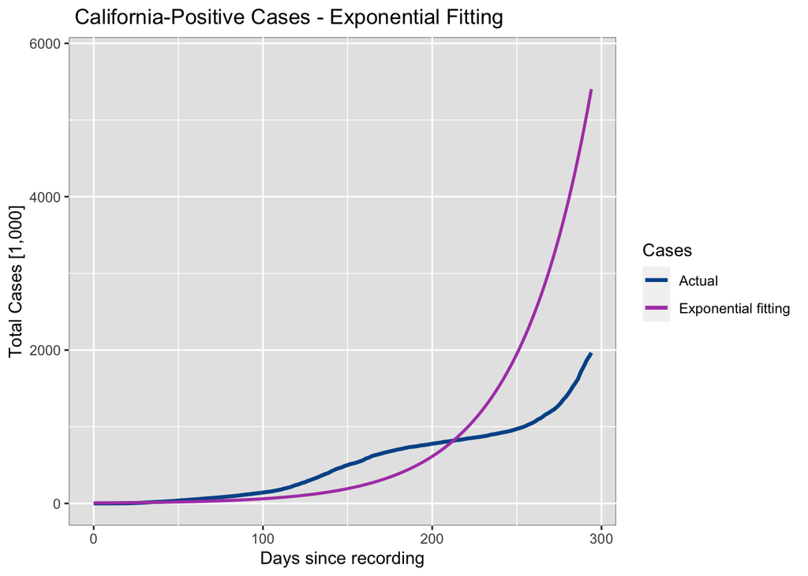

```r
# Exponential fitting
CALIF_2[nrow(CALIF_2)+3,] <- NA

CALIF_2$Future.x <- seq.int(nrow(CALIF_2))-1

CALIF_2$y.exp<-a.exponential*exp(Exp.model_1$coeff[2]*CALIF_2$Future.x)

p <- ggplot() +
  geom_line(data = CALIF_2, aes(days, positive/1000, color = "Actual"), size = 1.15) +
  geom_line(data = CALIF_2, aes(days, y.exp/1000, color = "Exponential fitting"), size = 0.9) +
  labs(title=" California-Positive Cases - Exponential Fitting",
          x ="Days since recording",
          y = "Total Cases [1,000]") +
  scale_color_manual(name = "Cases",
                     values = c("Actual" = "#005496", "Exponential fitting" = "#AF46B4"))


p + theme(panel.background = element_rect(fill='gray90', colour='#999999'))
```

### Power fitting

Power models of the form $y=ax^b$ have the independent raised to a power.

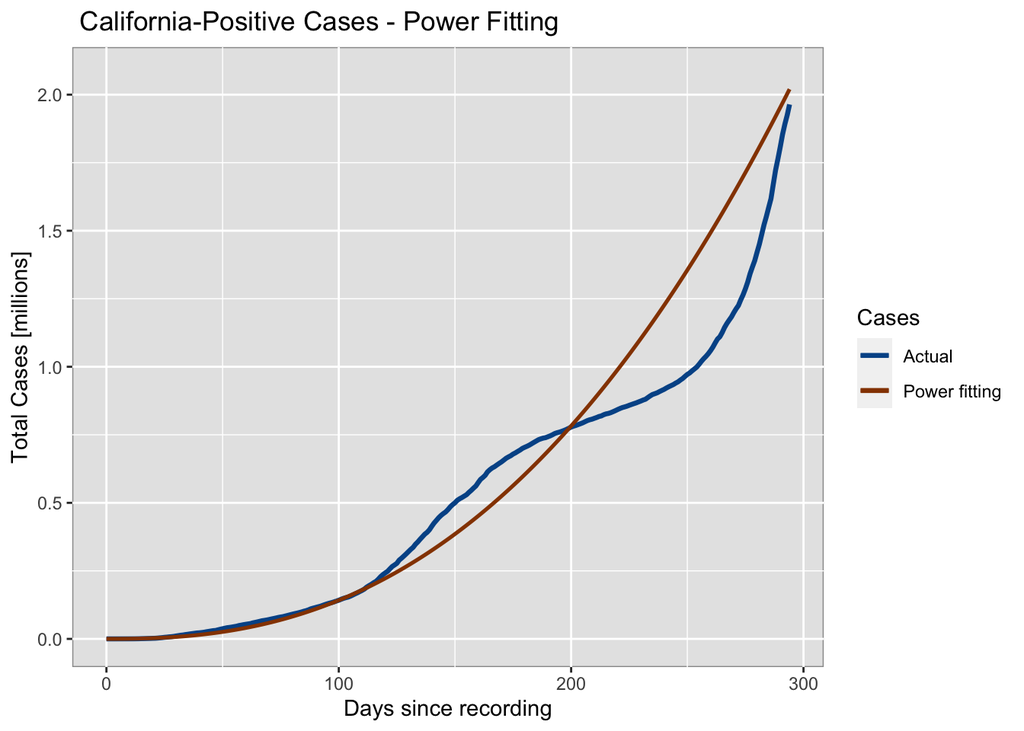

```r
# Power
CALIF_2$yZero     <- CALIF_2$positive - CALIF_2$positive[1]
CALIF_2$LN.yZero  <- log(CALIF_2$yZero)
CALIF_2$LN.x    <- log(CALIF_2$days)
k <- nrow(CALIF_1)

Power.Model <- lm(CALIF_2$LN.yZero[3:k] ~ CALIF_2$LN.x[3:k])
a.power<-exp(Power.Model$coeff[1])


# y = a * x^b + c;
# where x is 'CALIF_2$days'; a = exp(Power.Model$coeff[1]) ;
# b = Power.Model$coeff[2];
# and c = CALIF_2$positive[1] (the first value in the series)

CALIF_2$y.power <- a.power*(CALIF_2$Future.x^Power.Model$coeff[2])+CALIF_2$positive[1]


p <- ggplot() +
  geom_line(data = CALIF_2, aes(days, positive/1000000, color = "Actual"), size = 1.15) +
  geom_line(data = CALIF_2, aes(days, y.power/1000000, color = "Power fitting"), size = 0.9) +
  labs(title=" California-Positive Cases - Power Fitting",
          x ="Days since recording",
          y = "Total Cases [millions]") +
  scale_color_manual(name = "Cases",
                     values = c("Actual" = "#005496", "Power fitting" = "#964200"))


p + theme(panel.background = element_rect(fill='gray90', colour='#999999'))
```

### Analysis

Now, it is a matter of determining which estimate fits the original data best. We could use *graphic methods* to visualize the differences between the estimated models and the actual data, which we did in the charts above. We see that the *Exponential* model grows much faster than the actual data. The *Power* model seems to follow the actual data quite closely.

We can also use numeric measures to estimate the quality of our estimations. A very simple approach is to analyze the residuals, that is the difference between actual and estimated values.

$~$

### Residuals

This section is under construction

$~$

## Time-series Algorithms

In this section we discuss approaches specific to time-series. In R, there is a variety of packages that can handle time-series (ts) objects.  
The first step is to identify the time series. In our case, that the ‘historical’ series and we will limit that to data for the state of California.

### Data Preparation, create time series

```r
# California dataset
# Extracts the column containing the number of positive cases
CAL_positive <- CALIF_2[,3]
```

```r
# Updates the latest date to use as end date in time series
end_date <- paste(
  substr(as.character(CALIF_1[1, 1]), 1, 4),
  substr(as.character(CALIF_1[1, 1]), 5, 6),
  substr(as.character(CALIF_1[1, 1]), 7, 8),
  sep = "-")
```

```r
# Creates a daily Date object - helps my work on dates
inds <- seq(as.Date("2020-03-04"), as.Date(end_date), by = "day")

# Creates a time series object
CAL_ts <- ts(CAL_positive,
           start = c(2020, as.numeric(format(inds[1], "%j"))),
           frequency = 365)
```

### Transform into a stationary time series by removing the trend

```r
# detrend with first difference
CAL_1_diff <- diff(CAL_ts)
```

### Fitting a ‘naive’ model with the forecast package

For more details about the theoretical underpinnings see [Hyndman and Athanasopoulos](https://otexts.com/fpp2/toolbox.html)

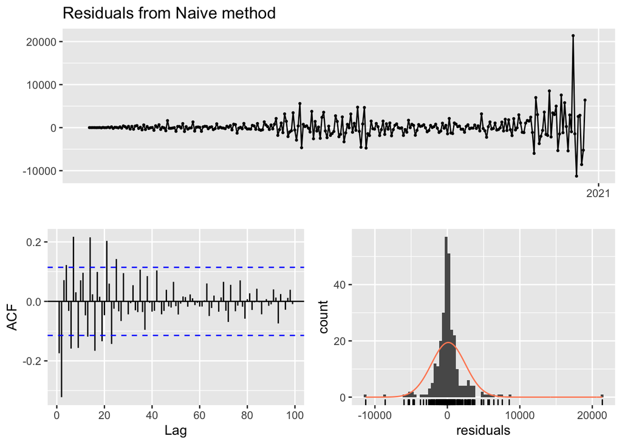

```r
# fitting
#naive forecast (snaive is for series with seasonality)
fit_CAL <- naive(CAL_1_diff)   # using the forecast package

# print(summary(fit_CAL))   # uncomment this line to get the model results
checkresiduals(fit_CAL)
```

Let’s look at the residuals chart above. The panel on the bottom left shows the Autocorrelation function for different lags. The ‘spikes’ in the bars indicate that the autocorrelation function is exceeding predetermined limits in a number of instances. Ideally, we want all the spikes to be within those limits, represented in the chart by dashed, blue lines.